# Problem Set 4

## Introduction to the assignment

We will be using the [Boston Housing Prices Data Set](http://archive.ics.uci.edu/ml/datasets/Housing).

```python
import IPython
import numpy as np
import scipy as sp
import pandas as pd

import matplotlib
%matplotlib inline
import matplotlib.pyplot as plt

#import statsmodels.api as sm
#import statsmodels.formula.api as smf
#from statsmodels.sandbox.regression.predstd import wls_prediction_std

import sklearn
from sklearn.linear_model import LinearRegression, LogisticRegression
from sklearn.model_selection import train_test_split
from sklearn.model_selection import KFold
from sklearn.metrics import mean_squared_error

import time
import math
```

```python
from sklearn.datasets import load_boston
bdata = load_boston()
```

## Part 1: Getting oriented

### 1.0 Understand the dataset

```python
# uncomment the following if you want to see a lengthy description of the dataset
print("keys:", bdata.keys())
print("feature names:",  bdata.feature_names)
print("data shape:", bdata.data.shape)
print("target shape", bdata.target.shape)
#print(bdata.DESCR)
#print ("-"*80)
```

```
keys: dict_keys(['data', 'target', 'feature_names', 'DESCR'])
feature names: ['CRIM' 'ZN' 'INDUS' 'CHAS' 'NOX' 'RM' 'AGE' 'DIS' 'RAD' 'TAX' 'PTRATIO'
 'B' 'LSTAT']
data shape: (506, 13)
target shape (506,)
```

### Create Dataframes for predictors, response and combined data

```python
print('\nPredictor Data is of type' , type(bdata.data), '\nInput shape: ', bdata.data.shape)
print('\nTarget is of type: ' , type(bdata.target) , '\nTarget shape: ', bdata.target.shape)
```

```
Predictor Data is of type <class 'numpy.ndarray'>
Input shape:  (506, 13)

Target is of type:  <class 'numpy.ndarray'>
Target shape:  (506,)
```

```python
#Create Dataframe from the ndarray of input data
boston_df =  pd.DataFrame(bdata.data)
print(boston_df.head())
```

```
        0     1     2    3      4      5     6       7    8      9     10  \
0  0.00632  18.0  2.31  0.0  0.538  6.575  65.2  4.0900  1.0  296.0  15.3
1  0.02731   0.0  7.07  0.0  0.469  6.421  78.9  4.9671  2.0  242.0  17.8
2  0.02729   0.0  7.07  0.0  0.469  7.185  61.1  4.9671  2.0  242.0  17.8
3  0.03237   0.0  2.18  0.0  0.458  6.998  45.8  6.0622  3.0  222.0  18.7
4  0.06905   0.0  2.18  0.0  0.458  7.147  54.2  6.0622  3.0  222.0  18.7

       11    12
0  396.90  4.98
1  396.90  9.14
2  392.83  4.03
3  394.63  2.94
4  396.90  5.33
```

```python
#Add column names
boston_df.columns = bdata.feature_names
X_df = boston_df
print('After adding Feature Names: \n', boston_df.head())
```

```
After adding Feature Names:
       CRIM    ZN  INDUS  CHAS    NOX     RM   AGE     DIS  RAD    TAX  \
0  0.00632  18.0   2.31   0.0  0.538  6.575  65.2  4.0900  1.0  296.0
1  0.02731   0.0   7.07   0.0  0.469  6.421  78.9  4.9671  2.0  242.0
2  0.02729   0.0   7.07   0.0  0.469  7.185  61.1  4.9671  2.0  242.0
3  0.03237   0.0   2.18   0.0  0.458  6.998  45.8  6.0622  3.0  222.0
4  0.06905   0.0   2.18   0.0  0.458  7.147  54.2  6.0622  3.0  222.0

   PTRATIO       B  LSTAT
0     15.3  396.90   4.98
1     17.8  396.90   9.14
2     17.8  392.83   4.03
3     18.7  394.63   2.94
4     18.7  396.90   5.33
```

```python
boston_df['MEDV'] = bdata.target
print('After adding Target column: \n', boston_df.head())
```

```
After adding Target column:
       CRIM    ZN  INDUS  CHAS    NOX     RM   AGE     DIS  RAD    TAX  \
0  0.00632  18.0   2.31   0.0  0.538  6.575  65.2  4.0900  1.0  296.0
1  0.02731   0.0   7.07   0.0  0.469  6.421  78.9  4.9671  2.0  242.0
2  0.02729   0.0   7.07   0.0  0.469  7.185  61.1  4.9671  2.0  242.0
3  0.03237   0.0   2.18   0.0  0.458  6.998  45.8  6.0622  3.0  222.0
4  0.06905   0.0   2.18   0.0  0.458  7.147  54.2  6.0622  3.0  222.0

   PTRATIO       B  LSTAT  MEDV
0     15.3  396.90   4.98  24.0
1     17.8  396.90   9.14  21.6
2     17.8  392.83   4.03  34.7
3     18.7  394.63   2.94  33.4
4     18.7  396.90   5.33  36.2
```

Note: boston_df is the main dataframe that contains all our data (both features and response). We will derive columns, Series and nparrays based on this dataframe.

### 1.1 Use existing libraries

Soon, you will write your own gradient descent algorithm, which you will then use to minimize the squared error cost function. First, however, let's use the canned versions that come with Python, to make sure we understand what we're aiming to achieve.

Using the same Boston housing prices dataset, use the [Linear Regression class](http://scikit-learn.org/stable/modules/generated/sklearn.linear_model.LinearRegression.html) from sklearn or the [OLS class](http://wiki.scipy.org/Cookbook/OLS) from SciPy to explore the relationship between median housing price and number of rooms per house. Do this by first (a) regressing the housing price on the number of rooms per house, and then (b) regressing the housing price on the number of rooms per house and the (number of rooms per house) squared. Interpret your results.

```python
#Run only once
X = boston_df.drop('MEDV', axis=1)
print('Features Dataframe X: \n', X.head())
```

```
Features Dataframe X:
       CRIM    ZN  INDUS  CHAS    NOX     RM   AGE     DIS  RAD    TAX  \
0  0.00632  18.0   2.31   0.0  0.538  6.575  65.2  4.0900  1.0  296.0
1  0.02731   0.0   7.07   0.0  0.469  6.421  78.9  4.9671  2.0  242.0
2  0.02729   0.0   7.07   0.0  0.469  7.185  61.1  4.9671  2.0  242.0
3  0.03237   0.0   2.18   0.0  0.458  6.998  45.8  6.0622  3.0  222.0
4  0.06905   0.0   2.18   0.0  0.458  7.147  54.2  6.0622  3.0  222.0

   PTRATIO       B  LSTAT
0     15.3  396.90   4.98
1     17.8  396.90   9.14
2     17.8  392.83   4.03
3     18.7  394.63   2.94
4     18.7  396.90   5.33
```

#### *Define Helper*: Call Existing Library function (SKLearn's Linear Regression)

```python
#### Function to call sklearn Linear Regression on dataframe columns
#### No return value, simply prints the coefficients and other important parameters
#X, y can be np arrays or dataframes
def sk_ols(X, y, target_col="Response", feature_list=[]):
    if feature_list==[]:  #Regress on all features by default
        feature_list = X.columns.tolist()

    x_df = X.ix[:,feature_list]

    #Create LinearRegression object, fit the data
    lm= LinearRegression()
    lm.fit(x_df, y)

    #Print findings.
    print('\nSKLearn Linear Regression\n-------------------------')
    print('Model :', target_col, ' vs ', feature_list, '\n')
    print('Number of Features               :' , len(feature_list))
    print('Intercept Value                  :' , lm.intercept_)
    print('Coefficient Values (No intercept):' , lm.coef_)

    return lm, lm.intercept_, lm.coef_
```

#### Model 1 : MEDV vs RM

```python
#Prepare data
X1 = pd.DataFrame(X['RM'], columns=['RM'])
print(X1.head())
y=boston_df['MEDV']

#Fit the model
lm1, _,  model_1_coefs = sk_ols(X1, y, target_col="MEDV")
model_1_beta = model_1_coefs[0]

#Test RMSE
print('\nRMSE = ', np.sqrt(mean_squared_error(y, X1.dot(model_1_coefs))))
```

```
      RM
0  6.575
1  6.421
2  7.185
3  6.998
4  7.147

SKLearn Linear Regression
-------------------------
Model : MEDV  vs  ['RM']

Number of Features               : 1
Intercept Value                  : -34.6706207764
Coefficient Values (No intercept): [ 9.10210898]

RMSE =  35.2938025267
```

**Interpretation:** Model 1 = (MEDV vs RM)

This model says that the Number of Rooms (RM) feature is positively associated with the Median Price of a house in Boston. For every unit increase in the average number of rooms, the corresponding median value of the Boston house increases by 9102.1 USD.

The RMSE value of 35.29 suggests that this a bad model. It is too simplistic. (Also, since RMSE is dependent on scale of y, and number of data points, we cannot say with certainty that this is a bad model)

#### Model 2 : MEDV vs RM and RM^2

```python
#Prepare the data
X2= pd.DataFrame(X['RM'], columns=['RM'])
X2['RMsquared'] = X2['RM']**2
print(X2.head())

#y=boston_df['MEDV']  #Previously calculated for model 1

#Fit the model
lm2, _,model_2_coefs = sk_ols(X2, y, target_col="MEDV")

#Test RMSE
print('\nRMSE = ' , np.sqrt(mean_squared_error(y, X2.dot(model_2_coefs))))
```

```
      RM  RMsquared
0  6.575  43.230625
1  6.421  41.229241
2  7.185  51.624225
3  6.998  48.972004
4  7.147  51.079609

SKLearn Linear Regression
-------------------------
Model : MEDV  vs  ['RM', 'RMsquared']

Number of Features               : 2
Intercept Value                  : 66.0588474848
Coefficient Values (No intercept): [-22.64326237   2.47012384]

RMSE =  66.3467635856
```

**Interpretation:** Model 2 = (MEDV vs RM, RM squared)

This model says that the Number of Rooms (RM) feature is associated with the Median Price of a house in Boston. For every unit increase in the average number of rooms, the corresponding median value of the Boston house increases by an amout -22.6 (RM) + 2.47(RM^2). The median value of the house is affected.

However, based on the RMSE value of 66.34, we can say that this is possibly a bad model, and definitely worse than the previous model. (Also, since RMSE is dependent on scale of y, and number of data points, we cannot say with certainty that this is a bad model)

```python
print('Note: X1, X2 are Dataframes used for the previous models')
type(X1)
```

```
Note: X1, X2 are Dataframes used for the previous models
```

```
pandas.core.frame.DataFrame
```

### 1.2 Training and testing

Chances are, for the above problem you used all of your data to fit the regression line. In some circumstances this is a reasonable thing to do, but often this will result in overfitting. Let's redo the above results the ML way, using careful cross-validation. Since you are now experts in cross-validation, and have written your own cross-validation algorithm from scratch, you can now take a shortcut and use the libraries that others have built for you.

Using the [cross-validation functions](http://scikit-learn.org/stable/modules/cross_validation.html) from scikit-learn, use 250-fold cross-validation to fit regression (a) above, i.e. the linear fit of housing price on number of rooms per house. Each fold of cross-validation will give you one slope coefficient and one intercept coefficient. Plot the distribution of the 250 slope coefficients, and draw a vertical line at the value of the slope coefficient that you estimated in 1.1 using the full dataset. What do you notice?

Note: please use 'random_state=1' and keep 'shuffle=False' when doing the KFold splitting to ensure reproducibility!

```python
#Prepare
features = ['RM']
X1 =boston_df[features]

#Create the split
kf = KFold(n_splits=250, shuffle=False, random_state=1)
kf.get_n_splits(X1)
```

```
250
```

```python
#Do K-fold Cross validation of sklearn OLS
coefs = []
cv_lm = LinearRegression()
for train_index, test_index in kf.split(X1):
    #print("TRAIN:", train_index, "TEST:", test_index)         #ndarray type

    #Split into train and test data
    X1_train, X1_test = X1.ix[train_index], X1.ix[test_index] #Fetch subset of df rows
    y_train, y_test = y[train_index], y[test_index]           #Fetch subset of Series rows

    #Fit the model
    cv_lm.fit(X1_train, y_train)
    beta= cv_lm.coef_[0]#unbox coef array of 1 element before appending
    coefs.append(beta)

#print(coefs)
```

```
Coefficient for RM in OLS (MEDV vs RM) =  9.10210898118
```

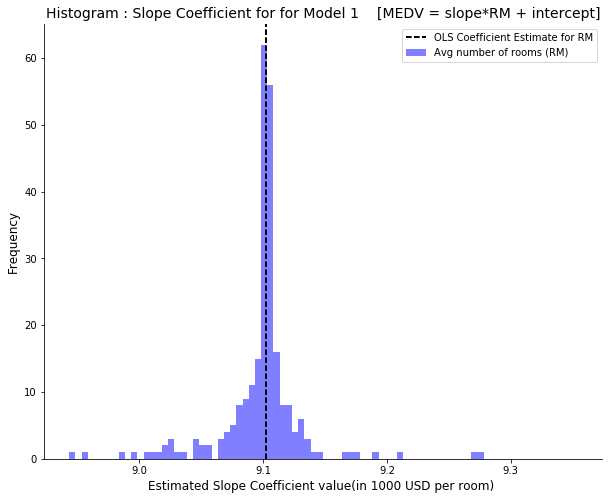

```python
#Plot HISTOGRAM - Coefficients
#Prepare the data
print('Coefficient for RM in OLS (MEDV vs RM) = ', model_1_beta)

#Prepare the plot
plt.figure(figsize=(10,8))
plt.title('Histogram : Slope Coefficient for for Model 1    [MEDV = slope*RM + intercept]', fontsize=14)
plt.xlabel('Estimated Slope Coefficient value(in 1000 USD per room) ', fontsize=12)
plt.ylabel('Frequency', fontsize=12)
plt.grid(False)
#plt.xticks(bin_list)

#Plot the data
binwidth = 0.005
bin_list = np.arange(min(coefs), 9.35 + binwidth, binwidth)
plt.hist(coefs, bins= bin_list, facecolor='blue', alpha=0.5, label = 'Avg number of rooms (RM)')

#Add a line
ax = plt.gca()
ax.axvline(model_1_beta, color='k', linestyle='dashed', linewidth=2, label = 'OLS Coefficient Estimate for RM')

#Remove spines on right and top
ax.spines['top'].set_visible(False)
ax.spines['right'].set_visible(False)

plt.legend()
plt.show()
```

#### Plot Interpretation:

The above plot shows that the estimated coefficients (beta1) of the bivariate model follow a normal distribution as expected. Our model's estimation of 9.102 seems to be very close to the median value obtained across 250 Cross validated linear regression tests.

### 1.3 Regression lines

Create a scatterplot of housing price on rooms per house, and add the two regression lines from 1.1 (or 1.2 if you prefer to do so). Show the linear regression line in red, and the linear+quadratic regression line (which may have curvature) in blue. Label these two regression lines with the corresponding regression equations (i.e. the slope and intercept of the line).

Bonus: Add the 95% confidence bands (i.e., the area that has a 95% chance of containing the true regression line) to each of these lines.

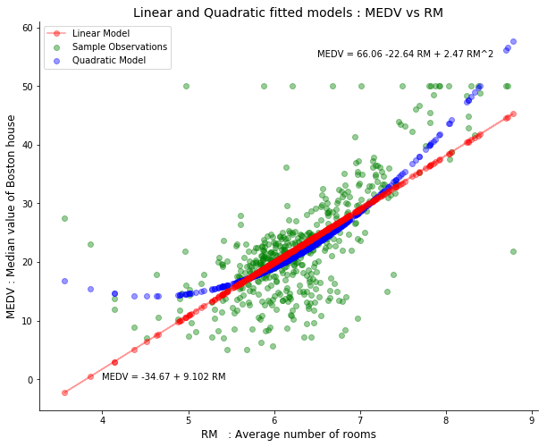

```python
#Prepare the data
x = X1['RM'].values
actuals = y.values

model1_preds = lm1.predict(X1)
model2_preds = lm2.predict(X2)

#Prepare the plot
plt.figure(figsize=(10,8))
plt.title('Linear and Quadratic fitted models : MEDV vs RM', fontsize = 14)
plt.xlabel('RM   : Average number of rooms', fontsize = 12)
plt.ylabel('MEDV : Median value of Boston house', fontsize = 12)

#Add text blurbs
model_1_text = "MEDV = -34.67 + 9.102 RM"
model_2_text = "MEDV = 66.06 -22.64 RM + 2.47 RM^2"
plt.text(s=model_1_text, x=4,  y= 0)
plt.text(s=model_2_text, x=6.5, y= 55)

#Plot the data
plt.scatter(x, actuals, c='g', alpha = 0.4, label = 'Sample Observations')
plt.scatter(x, model2_preds, c='b', alpha=0.4, label = 'Quadratic Model')
plt.plot(x, model1_preds, 'r-o', alpha=0.4, label = 'Linear Model')


# configure legend
plt.legend(loc='best')

#Remove spines on right and top
ax = plt.gca()
ax.spines['top'].set_visible(False)
ax.spines['right'].set_visible(False)
```

Let's jazz this plot up!

1. Add confidence interval bands
2. Add smooth lines instead of dots for predicted Curves for Linear and Quadratic Fit

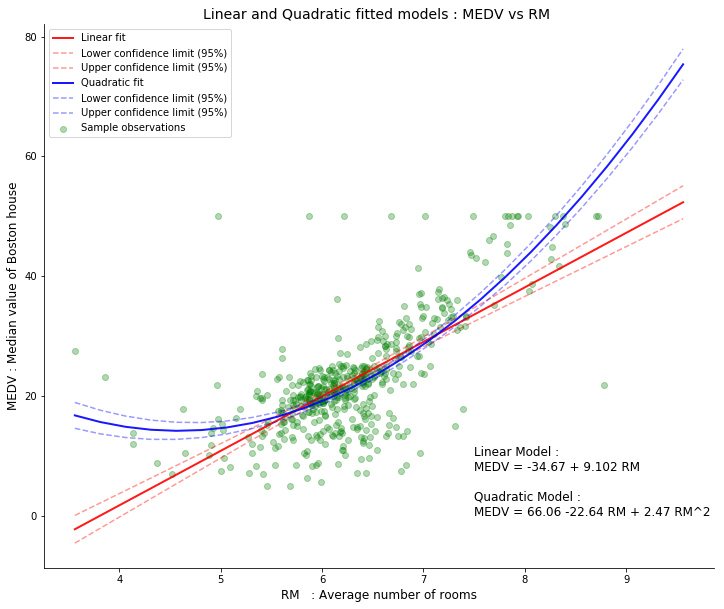

```python
# Prepare the data
x = X1['RM'].values
actuals = y.values
model1_preds = lm1.predict(X1)
model2_preds = lm2.predict(X2)
##################################################
#For Smooth plotting of linear and quadratic fit
# create series of equally spaced test x-values for smooth plot
p_x = np.arange(np.min(x),np.max(x)+1, 0.25)

# now predict y based on test x-values
p_y1 = 9.102 * p_x -34.67               #Model 1 = MEDV vs RM
p_y2 = 66.06 -22.64*p_x + 2.47*p_x*p_x  #Model 2 = MEDV vs RM, RM^2

###################################################
#For Finding confidence intervals of the linear and quadratic fit

# calculate the y-error (residuals)
y_err1 = actuals - model1_preds
y_err2 = actuals - model2_preds

# sum of the squares of the residuals
sq_err1 = np.sum(np.power(y_err1,2))
sq_err2 = np.sum(np.power(y_err2,2))

# now calculate confidence intervals for new test x-series
mean_x = np.mean(x) # mean of x
n = len(x)          # number of samples in original fit
t = 1.96            # appropriate t value (where n=506, two tailed 95%)

confs1 = t * np.sqrt((sq_err1/(n-2))*(1.0/n + (np.power((p_x - mean_x),2)/
            ((np.sum(np.power(x,2)))-n*(np.power(mean_x,2))))))

confs2 = t * np.sqrt((sq_err2/(n-2))*(1.0/n + (np.power((p_x - mean_x),2)/
            ((np.sum(np.power(x,2)))-n*(np.power(mean_x,2))))))

# get lower and upper confidence limits based on predicted y and confidence intervals
lower1 = p_y1 - abs(confs1)
upper1 = p_y1 + abs(confs1)

lower2 = p_y2 - abs(confs2)
upper2 = p_y2 + abs(confs2)
####################################################

#Prepare the plot
plt.figure(figsize=(12,10))
plt.title('Linear and Quadratic fitted models : MEDV vs RM ', fontsize = 14)
plt.xlabel('RM   : Average number of rooms', fontsize = 12)
plt.ylabel('MEDV : Median value of Boston house', fontsize = 12)

#Add text blurbs
model_1_text = "MEDV = -34.67 + 9.102 RM"
model_2_text = "MEDV = 66.06 -22.64 RM + 2.47 RM^2"
plt.text(s=('Linear Model :\n' +model_1_text + '\n\nQuadratic Model :\n' + model_2_text), x=7.5,  y= 0, fontsize=12)


#Plot sample data and fitted models
plt.scatter(x, actuals, c='g', alpha = 0.3 , label='Sample observations')

#Plot smooth Linear Fit and confidence limits
plt.plot(p_x, p_y1, 'r'  , alpha = 0.9 ,  label = 'Linear fit', linewidth =2)
plt.plot(p_x,lower1,'r--', alpha = 0.4, label='Lower confidence limit (95%)')
plt.plot(p_x,upper1,'r--', alpha = 0.4, label='Upper confidence limit (95%)')

#Plot smooth Quadratic Fit and confidence limits
plt.plot(p_x, p_y2, c='b', alpha = 0.9, label = 'Quadratic fit', linewidth =2)
plt.plot(p_x,lower2,'b--', alpha = 0.4, label='Lower confidence limit (95%)')
plt.plot(p_x,upper2,'b--', alpha = 0.4, label='Upper confidence limit (95%)')

# configure legend
plt.legend(loc='best')

#Remove spines on right and top
ax = plt.gca()
ax.spines['top'].set_visible(False)
ax.spines['right'].set_visible(False)

# show the plot
plt.show()
```

#### Plot Interpretation

Both models do well in the central portion of the graph, as there are many sample data points there which give the model a better fit. The extreme ends of the graph have fewer sample observations, and hence don't have as much weightage in the fit.

## Part 2: Gradient descent: Linear Regression

This is where it gets fun!

### 2.1 Implement gradient descent with one independent variable (Average rooms per house)

Implement the batch gradient descent algorithm. Use the version you implement to regress the housing price on the number of rooms per house. Experiment with 3-4 different values of the learning rate *R*, and do the following:

- Report the values of alpha and beta that minimize the loss function
- Report the number of iterations it takes for your algorithm to converge (for each value of *R*)
- Report the total running time of your algorithm, in seconds

#### *Define Helper*: Cost Function (Vanilla OLS)

The following function helps calculate the value of OLS loss function for a given set of feature data, response data and coefficients.

```python
def compute_cost(X, y, theta):
    err = X.dot(theta) - y
    n = len(y)
    J = np.sum((err**2))/2/n
    return J
```

#### *Define* : Gradient Descent to minimize OLS for Bivariate Linear Regression

```python
"""
    Function
    --------
    bivariate_ols: Gradient Decent to minimize OLS. Used to find coefficients of bivariate OLS Linear regression

    Parameters
    ----------
    xvalues, yvalues : narray xvalues: independent variable; yvalues: dependent variable
    R: float, Learning rate
    MaxIterations: Int, maximum number of iterations

    Returns
    -------
    alpha: float, intercept
    beta: float, co-efficient
    ttaken: time taken
    it: number of iterations
    convergence: logical, convergence achieved?
"""

def bivariate_ols(xvalues, yvalues, R=0.01, MaxIterations=10000, init_alpha =0, init_beta=0, verbose=False):
    tic=time.time()
    eps   = 0.00005
    n = len(yvalues)
    p = len(xvalues[0])

    convergence = False
    old_theta = np.array([init_alpha, init_beta]) #needed as np.array for computing cost
    old_cost=compute_cost(xvalues, yvalues, old_theta)

    if(verbose==True):
        print('\n Bivariate OLS \n-----------------')
        print('Learning rate        : ', R)
        print('Initial coefficients : ', old_theta.tolist())
        print('Maximum Iterations   : ', MaxIterations)


    num_iter=  1
    cost_history  = []
    theta_history = []
    cost_history.append(old_cost)
    theta_history.append(old_theta.tolist())


    for i in range(MaxIterations-1):
        #Calculate Gradient for OLS
        err = yvalues - xvalues.dot(old_theta)
        gradient = -xvalues.T.dot(err)/n

        #Update the coefficients
        theta = old_theta - R*gradient

        #Calculate current cost
        cost= compute_cost(xvalues, yvalues, theta)

        #Store the costs
        cost_history.append(cost)
        theta_history.append(theta.tolist())
        num_iter+=1

        #Check for convergence
        if(old_cost - cost <= eps):
            print('\nThe loss function has leveled off.')
            convergence= True
            break

        theta_change = abs(theta - old_theta)
        if all( diff <= eps for diff in theta_change) == True:
            print('\nThe coefficients have leveled off.')
            convergence = True
            break

        old_cost  = cost
        old_theta = theta

    toc = time.time()
    ttaken=toc-tic
    if(verbose==True):
        print('\nalpha  (intercept)   : ', theta[0])
        print('beta   (coefficient) : ', theta[1])
        print('Time taken           : ', ttaken)
        print('Iterations           : ', num_iter)
        print('Convergence?         : ', convergence)
        #print('\nLoss history         : ', cost_history)
        #print('\nTheta history        : ', theta_history)
        print("------------------------------------------")

    return theta[0], theta[1], ttaken, num_iter, convergence, cost_history, theta_history
```

#### *Define Helper*: Standardize a dataframe, Series or np array before OLS

- This function has been moved here from section 2.2, to be defined before helper function "prepare_df_for_ols" that follows.
- CAUTION: This function returns a tuple of 3 values; the standardized data, mean and sd.
- This method works on both dataframes and ndarrays.

```python
def standardize(raw_data):
    """
    standardizes raw data and returns
    standardized data, mean by column, sd by column
    """
    mu = np.mean(raw_data, axis = 0)
    sd = np.std(raw_data, axis = 0)
    return (raw_data - mu) / sd, mu, sd
```